# Names: Aidan Hussain

# Project Title: Billionaire Analysis

# Website: https://aidanhussain.github.io/cmps3160project/

# Data Set 1: Billionaires

Link: https://think.cs.vt.edu/corgis/csv/billionaires/

I am considering working with this dataset because I think it could be an interesting exploration of factors that are conducive to financial success. One of my (and I'm sure many of my classmates) goals is to become wealthy; as such, I think that seeking an objective analysis of determinants of wealth could be very interesting. Specifically, I'd like to examine the impacts of gender, nation of origin, and industry have on accumulating wealth. Additionally, I believe there is a lot of analysis to be done regarding the effects of whether wealth was inherited or not on life decisions (e.g., do people who inherit their wealth tend to enter a specific type of industry? Are they more likely to be hedge fund managers than those who do not inherit wealth? Things like this...).

This data set consists of billionaires at three points in time (1996, 2001, 2014). The dataset includes 22 variables, and is very comprehensive. I believe this dataset lends itself to interesting analysis using the techniques we have learned thus far in this course, and I think that the nature of the data suggests that interesting revelations may arise from analyzing the data.

While I have yet to truly finalize one question I would like to answer from analyzing this dataset, an example of an intriguing question could stem from this area of focus: What industries seem to be relatively conducive for those who did not inherit their wealth becoming billionaires? What industries seem to be more difficult for non-inheritors to break into to generate massive wealth?

```python
!git clone https://github.com/aidanhussain/cmps3160project.git
%cd cmps3160project
```

```
Cloning into 'cmps3160project'...
remote: Enumerating objects: 6, done.
remote: Counting objects: 100% (6/6), done.
remote: Compressing objects: 100% (4/4), done.
remote: Total 6 (delta 0), reused 0 (delta 0), pack-reused 0
Receiving objects: 100% (6/6), 96.88 KiB | 1.76 MiB/s, done.
/content/cmps3160project
```

```python
import pandas as pd

billionaires_df = pd.read_csv("billionaires.csv")
billionaires_df.dtypes #Check dtypes of each column
```

```
name                         object
rank                          int64
year                          int64
company.founded               int64
company.name                 object
company.relationship         object
company.sector               object
company.type                 object
demographics.age              int64
demographics.gender          object
location.citizenship         object
location.country code        object
location.gdp                float64
location.region              object
wealth.type                  object
wealth.worth in billions    float64
wealth.how.category          object
wealth.how.from emerging       bool
wealth.how.industry          object
wealth.how.inherited         object
wealth.how.was founder         bool
wealth.how.was political       bool
dtype: object
```

Thankfully, the dtypes were set correctly by Pandas when I imported the CSV! Now, let's take a look at what data we have:

```python
billionaires_df = billionaires_df.dropna() #Ensure all data rows are complete...better to work with complete data...
billionaires_df.head(10)
```

|  | name | rank | year | company.founded | company.name | company.relationship | company.sector | company.type | demographics.age | demographics.gender | ... | location.gdp | location.region | wealth.type | wealth.worth in billions | wealth.how.category | wealth.how.from emerging | wealth.how.industry | wealth.how.inherited | wealth.how.was founder | wealth.how.was political |
| --- | --- | --- | --- | --- | --- | --- | --- | --- | --- | --- | --- | --- | --- | --- | --- | --- | --- | --- | --- | --- | --- |
| 0 | Bill Gates | 1 | 1996 | 1975 | Microsoft | founder | Software | new | 40 | male | ... | 8.100000e+12 | North America | founder non-finance | 18.5 | New Sectors | True | Technology-Computer | not inherited | True | True |
| 1 | Bill Gates | 1 | 2001 | 1975 | Microsoft | founder | Software | new | 45 | male | ... | 1.060000e+13 | North America | founder non-finance | 58.7 | New Sectors | True | Technology-Computer | not inherited | True | True |
| 2 | Bill Gates | 1 | 2014 | 1975 | Microsoft | founder | Software | new | 58 | male | ... | 0.000000e+00 | North America | founder non-finance | 76.0 | New Sectors | True | Technology-Computer | not inherited | True | True |
| 3 | Warren Buffett | 2 | 1996 | 1962 | Berkshire Hathaway | founder | Finance | new | 65 | male | ... | 8.100000e+12 | North America | founder non-finance | 15.0 | Traded Sectors | True | Consumer | not inherited | True | True |
| 4 | Warren Buffett | 2 | 2001 | 1962 | Berkshire Hathaway | founder | Finance | new | 70 | male | ... | 1.060000e+13 | North America | founder non-finance | 32.3 | Traded Sectors | True | Consumer | not inherited | True | True |
| 5 | Carlos Slim Helu | 2 | 2014 | 1990 | Telmex | founder | Communications | privatization | 74 | male | ... | 0.000000e+00 | Latin America | privatized and resources | 72.0 | Non-Traded Sectors | True | Media | not inherited | True | True |
| 7 | Paul Allen | 3 | 2001 | 1975 | Microsoft | founder | technology | new | 48 | male | ... | 1.060000e+13 | North America | founder non-finance | 30.4 | New Sectors | True | Technology-Computer | not inherited | True | True |
| 8 | Amancio Ortega | 3 | 2014 | 1975 | Zara | founder | Fashion | new | 77 | male | ... | 0.000000e+00 | Europe | founder non-finance | 64.0 | Non-Traded Sectors | True | Retail, Restaurant | not inherited | True | True |
| 9 | Lee Shau Kee | 4 | 1996 | 1976 | Henderson Land Development | founder/chairman | real estate | new | 68 | male | ... | 1.600000e+11 | East Asia | self-made finance | 12.7 | Financial | True | Real Estate | not inherited | True | True |
| 10 | Larry Ellison | 4 | 2001 | 1977 | Oracle | founder | software | new | 56 | male | ... | 1.060000e+13 | North America | founder non-finance | 26.0 | New Sectors | True | Technology-Computer | not inherited | True | True |

10 rows × 22 columns

As you can see above, I was able to load the CSV file into this notebook. Thankfully, the original data source was well organized, so I did not have to make any meaningful changes to the data in order to display in a digestible and logical way. Now, let's start thinking about ETL by finding an interesting statistic and generating an interesting graph from this data set!

```python
#Average wealth of biollionaires by type of inheritance
billionaires_df.groupby(['wealth.how.inherited'])['wealth.worth in billions'].mean().sort_values(ascending=False)
```

```
wealth.how.inherited
spouse/widow                4.527119
father                      4.049186
not inherited               3.454490
3rd generation              3.240488
4th generation              2.774627
5th generation or longer    2.713793
Name: wealth.worth in billions, dtype: float64
```

Hmm, that's pretty interesting. On average, the wealthiest billionaires tend to primarily inherit their wealth from their spouse. The next closest group of inheritors inherit their welath from their father. The rest of the rankings are produced in the block above. Of course, this includes 3 different points in time, so some billionaires are double counted!

Intuitively, it makes sense that 3rd, 4th, and 5th generation inheritors are ranked as such because, as generations pass, the wealth likely becomes divided between a greater number of descendants, thus decreasing the individual inheritances of these billionaires. I'm sure they're doing just fine financially, though!

Now, let's see the breakdown by gender:

```python
#Average wealth of biollionaires by gender
billionaires_df.groupby(['demographics.gender'])['wealth.worth in billions'].mean().sort_values(ascending=False)
```

```
demographics.gender
female            3.830242
male              3.539510
married couple    1.300000
Name: wealth.worth in billions, dtype: float64
```

Perhaps surprisingly, women billionaires have a higher average wealth than their male counterparts--interesting! How about one more interesting statistic...let's see what geographic breakdown looks like:

```python
#Average wealth of biollionaires by region
billionaires_df.groupby(['location.region'])['wealth.worth in billions'].sum().sort_values(ascending=False)
```

```
location.region
North America               3803.0
Europe                      2545.8
East Asia                   1518.3
Latin America                570.4
Middle East/North Africa     313.4
South Asia                   221.1
Sub-Saharan Africa            78.1
0                              2.1
Name: wealth.worth in billions, dtype: float64
```

So on a total basis, North America nd Europe lead the way, with East Asia right behind!

Now, let's crate an interesting graphic. Perhaps, something to do with the number of billionaires per industry?

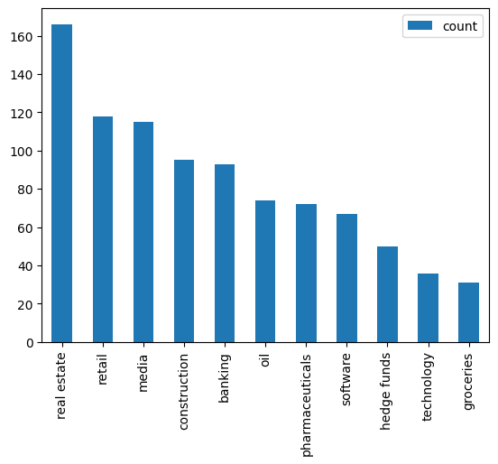

```python
#Let's visualie the # of billionares per sector
graph_vals = billionaires_df['company.sector'].value_counts()

graph_vals = graph_vals.to_frame()
graph_vals = graph_vals[graph_vals['company.sector'] > 30]
graph_vals = graph_vals.rename(columns={'company.sector' : 'count'})
graph_vals.plot.bar()
```

Perhaps real estate being the most frequent industry is not surprising--but construction at #4? groceries frequent enough to make the graph? Interesting! This variable graphed will be useful when diving into analyzing the dispersion of industry and source of wealth, so getting an idea of the overall distribution of values for the variable is important, no doubt.

# Collaboration Plan

For this project, I plan to work solo, so I will not need to collobrate with a partner. Yet, it is still crucial to formulate a plan to ensure that I stay on track regarding working on the project. As such, I plan to set aside a specific block of time each week to work on this project, thereby ensuring that I do not fall behind and risk submitting a project without the adequate level of detail expected.

```python
#Download as HTML...
from google.colab import drive
drive.mount('/content/drive')
```

```python
%cd /content/drive/MyDrive/'Colab Notebooks'

%%shell
jupyter nbconvert --to html CMPS3160Project.ipynb
```

```
  File "<ipython-input-81-e3701f091940>", line 4
    jupyter nbconvert --to html CMPS3160Project.ipynb
            ^
SyntaxError: invalid syntax
```